# Auswertung V4

#### Evaluation

| **Evaluation** | Die im ML-Prozess entstehenden Modelle müssen von den Entwicklern mittels verschiedener Metriken getestet werden. Diese Metriken bewerten die Ausgaben der trainierten Modelle. Die Regeln, nach denen d… |
| --- | --- |

[figure not shown]

| Frage | average | avrg_percentage | max_points |
| --- | --- | --- | --- |
| TG13 | 2.19 | 0.55 | 4 |

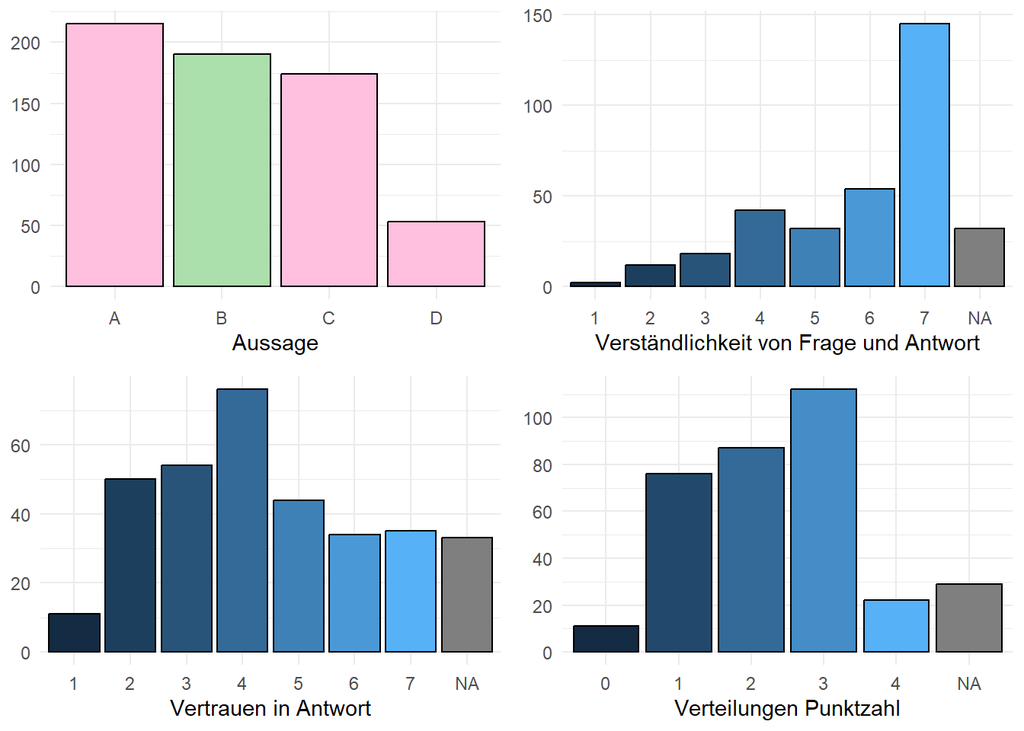

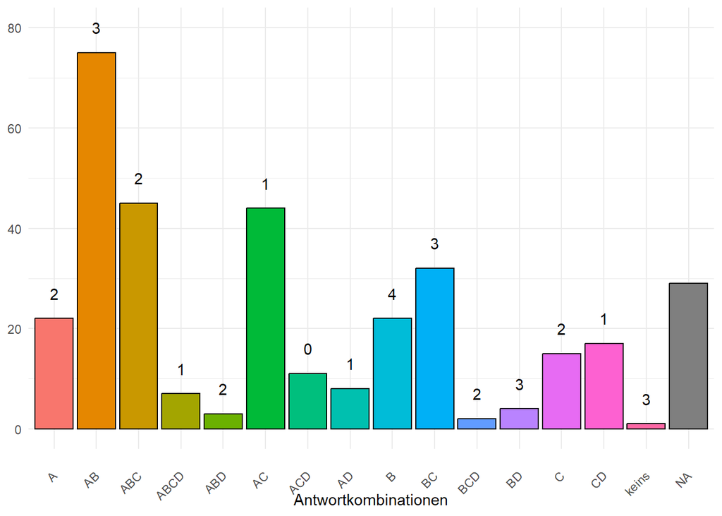

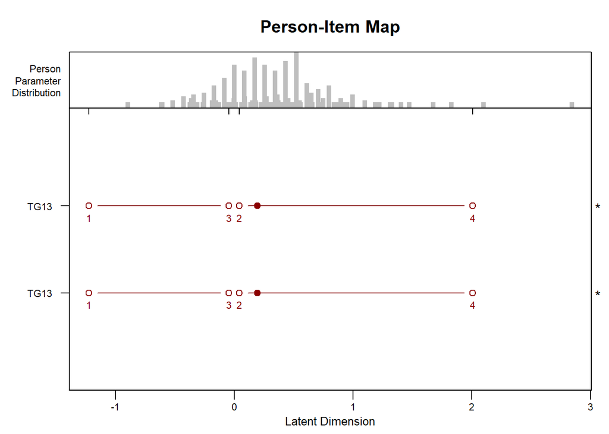

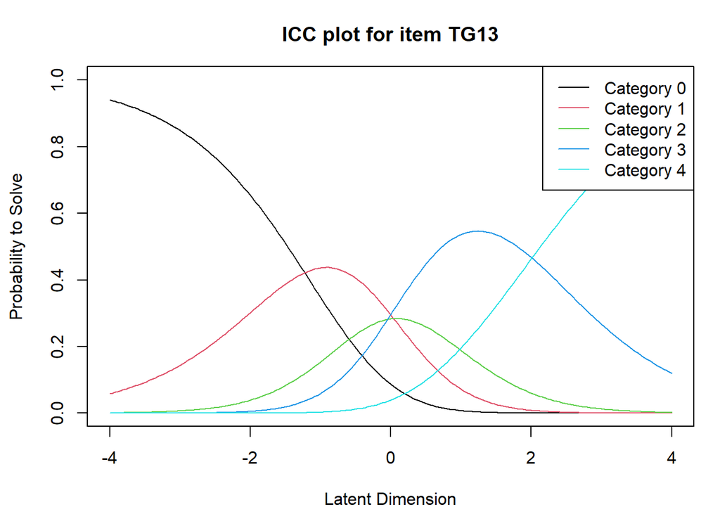

- **Inhalt:**
  - Schwelle 3 und 2 nah beieinander
  - Antwortoption D wird relativ selten gewählt. Könnte man weglassen, wurde aber oft genug gewählt und lässt sich aus Literatur ableiten.
  - Wie könnte man die Schwellen anpassen? –> **Unklar**
- **Verständnis**
  - Größtenteils verständlich, aber nicht ganz smooth
  - Liegt es an einer der Antwortoptionen?

#### Datenqualität

| **Datenqualität** | Die Trainingsdaten müssen in erster Linie das zu lösende Problem beschreiben. Beispielsweise sollten die Daten mit der gewählten Zielvariable korrelieren. Die Daten sollten darüber hinaus auf etwaige … |
| --- | --- |

| Frage | average | avrg_percentage | max_points |
| --- | --- | --- | --- |
| TG15 | 2.32 | 0.58 | 4 |

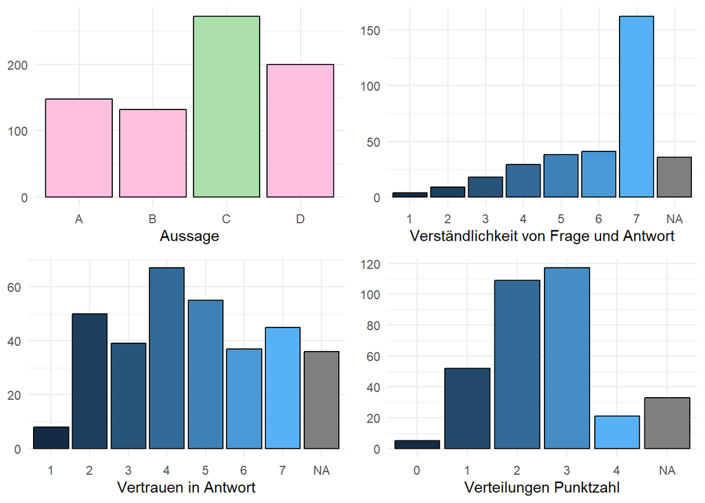

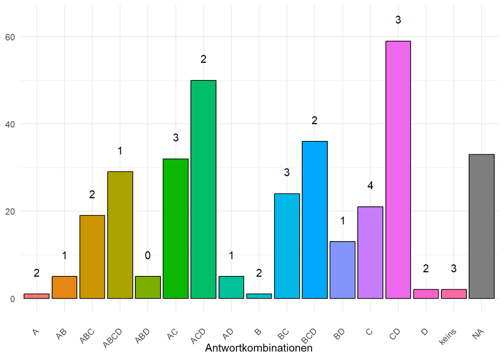

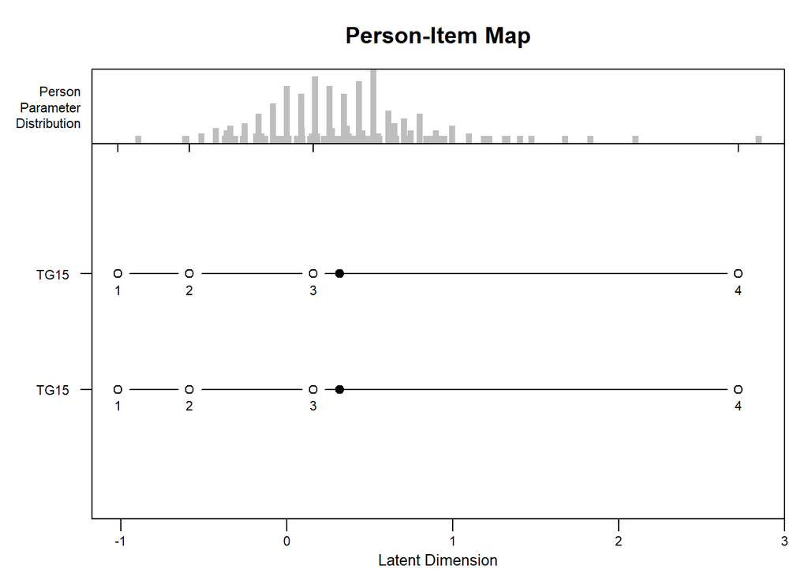

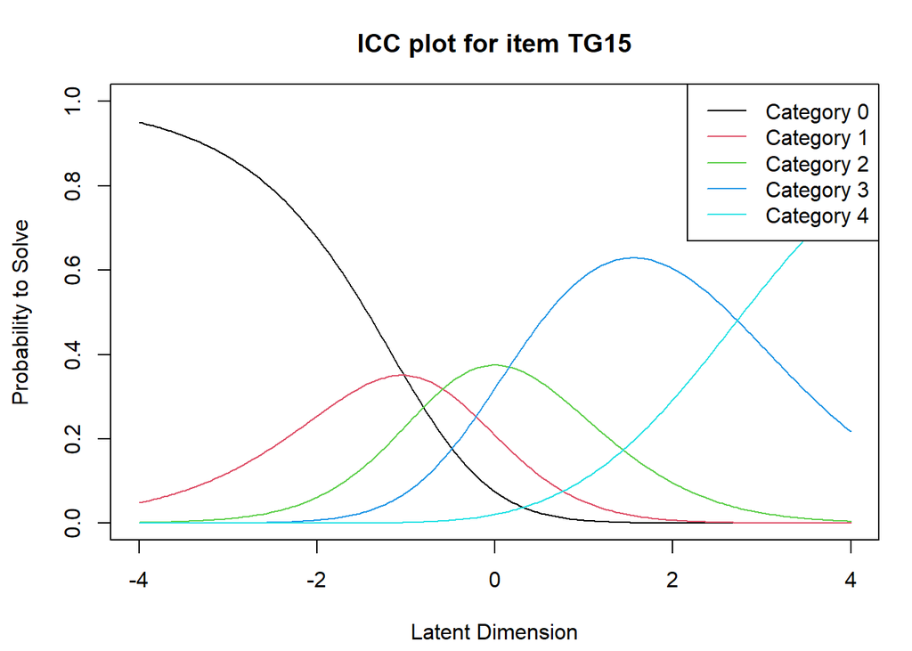

- **Inhalt:**
  - Schwellen 1 und 4 wieder sehr leicht/schwer, ansonsten gut verteilt
  - Insgesamt werden hier schon relativ viele Punkte erzielt
  - Bis darauf, dass es ein relativ einfaches Item ist: passt gut.
- **Verständnis**
  - sehr verständlich

# Fragebogen als Diagnoseinstrument

Hier finden sich ein paar Spielereien wie man die Daten bezüglich der vorhandenen Fehlvorstellungen auswerten könnte. Ich habe jetzt für jede Fehlvorstellung jeweils die zugehörigen Statements gesammelt und berechne den Durschnitt der angekreuzten Statements für jede Person. Anschließend habe ich einmal den Durschnitt über die ganze Gruppe berechnet. Hier lassen sich bestimmt auch schönere Auswertungsmethoden finden.

```r
#fehlend: GE04_03, GE12_01, GE12_04, GE14_02, "TG02_03", "TG13_01", "TG13_04", "TG15_02"
#doppelt: "GE08_04", "TG09_04"
c_mc_pb = c("GE02_01","GE04_01", "GE08_03", "GE10_03", "GE14_04", "TG02_01", "TG04_01", "TG09_02", "TG11_01")
c_mc_st = c("GE02_03", "GE10_01", "GE10_02", "TG04_03", "TG04_04", "TG11_02", "TG11_04", "TG15_04")
c_mc_ut = c("GE04_04", "GE14_03", "TG02_05", "TG09_04", "GE08_04", "TG15_01")
c_mc_ac = c("GE04_05", "TG02_04")
c_mc_cl = c("GE08_01", "GE08_04", "GE10_05", "GE12_03", "TG09_01", "TG09_04", "TG11_05", "TG13_03")
#mc_ex =

mc_data <- data %>%
  rowwise() %>%
  mutate(mc_pb = mean(c_across(all_of(c_mc_pb)), na.rm = TRUE)) %>%
  mutate(mc_st = mean(c_across(all_of(c_mc_st)), na.rm = TRUE)) %>%
  mutate(mc_ut = mean(c_across(all_of(c_mc_ut)), na.rm = TRUE)) %>%
  mutate(mc_ac = mean(c_across(all_of(c_mc_ac)), na.rm = TRUE)) %>%
  mutate(mc_cl = mean(c_across(all_of(c_mc_cl)), na.rm = TRUE)) %>%
  ungroup() %>%
  select(mc_pb, mc_st, mc_ut, mc_ac, mc_cl)
colnames(mc_data) <- c("Programmed Behaviour", "Raw Data Storage", "User-trained", "Autonomous Aqucisition", "Continous Learning")

compute_mc <- function(mc_data){
  mc_data <- mc_data %>%
    summarise(across(everything(), mean, na.rm=TRUE)) #%>%
    #pivot_longer(cols = everything(), names_to = "Fehlvorstellung", values_to = "Durschnnitt")
  return(mc_data)
}

mc_data_all <- compute_mc(mc_data)
```

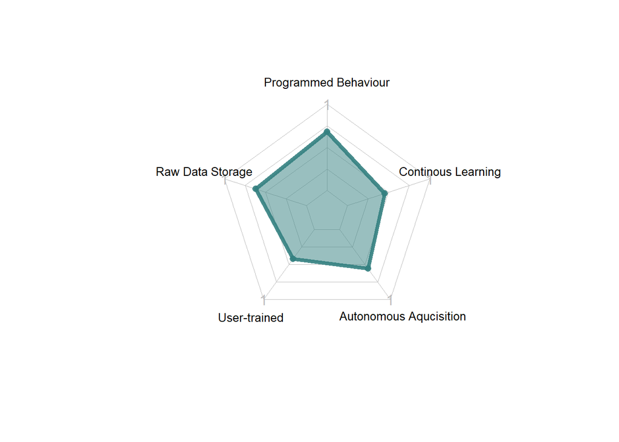

```r
library(fmsb)


mc_data_all <- rbind(rep(1,5) , rep(0,5) , mc_data_all)
radarchart(mc_data_all, axistype=2 ,
  #custom polygon
  pcol=rgb(0.2,0.5,0.5,0.9) , pfcol=rgb(0.2,0.5,0.5,0.5) , plwd=4 ,

  #custom the grid
  cglcol="grey", cglty=1, axislabcol="grey",  cglwd=0.8,

  #custom labels
  vlcex=0.8
)
```

**Problem:** Einproblematischer Fakt ist, dass wir für manche FV wie programmed behaviour viele Aussagen haben über die wir den Durschnitt bilden können. Dagegen hat die FV autonomous data aquisition beispielsweise nur jeweils ein Statement pro Technologie.

## Clusteranalyse

Man könnte hier noch Clusteranalysen durchführen und schauen, ob es verschiedene Cluster an Personen gibt, die ähnlich angekreuzt haben. Ich könnte mir zum Beispiel vorstellen, dass es ein Cluster von Leuten gibt, die sehr starke informatische Fehlvorstellungen haben.

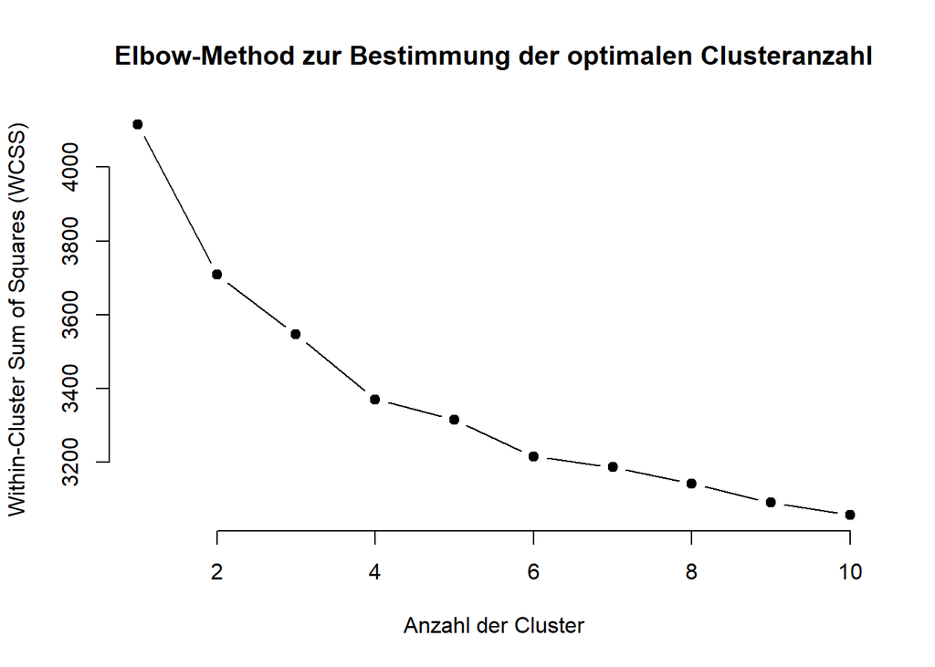

```r
library(klaR)
data_clustering <- data.frame(lapply(data_items, as.factor)) #%>%
  #filter(!if_all(everything(), is.na))
data_clustering <- na.omit(data_clustering)

# Funktion zur Berechnung von WCSS für k-modes
calculate_wcss <- function(data, max_clusters = 10) {
  wcss <- numeric(max_clusters)
  for (k in 1:max_clusters) {
    kmodes_result <- kmodes(data, modes = k, iter.max = 10)
    wcss[k] <- sum(kmodes_result$withindiff)
  }
  return(wcss)
}

# Berechne WCSS für Clusteranzahlen von 1 bis 10
wcss_values <- calculate_wcss(data_clustering, max_clusters = 10)

# Visualisiere den WCSS-Verlauf ("Elbow-Plot")
plot(1:10, wcss_values, type = "b", pch = 19, frame = FALSE,
     xlab = "Anzahl der Cluster",
     ylab = "Within-Cluster Sum of Squares (WCSS)",
     main = "Elbow-Method zur Bestimmung der optimalen Clusteranzahl")
```

```r
kmodes_result <- kmodes(data_clustering, modes = 5, iter.max = 10, weighted = FALSE)
data_clustering$Cluster <- as.factor(kmodes_result$cluster)

# Ausgabe des k-modes Ergebnisses
#print(kmodes_result)

# # Daten ins lange Format bringen
# data_clustering %>%
#   pivot_longer(cols = starts_with("GE")|starts_with("TG"), # Wähle alle Spalten, die mit "Var" beginnen
#                names_to = "variable",     # Spaltennamen in eine Spalte "variable" packen
#                values_to = "value") %>%
# # Heatmap zeichnen
#   ggplot(aes(x = variable, y = factor(Cluster), fill = as.numeric(value))) +
#     geom_tile(color = "white") +
#     #scale_fill_manual(values = c("0" = "lightblue", "1" = "darkblue")) +
#     labs(title = "Heatmap der Cluster", x = "Variablen", y = "Cluster") +
#     theme_minimal()

#for (i in 1:6) {
 # data_clustering_plot <- data_clustering %>%
  #  mutate(across(everything(), as.numeric)) %>%
   # rowwise() %>%
#    mutate(mc_pb = mean(c_across(all_of(c_mc_pb)), na.rm = TRUE)) %>%
 #   mutate(mc_st = mean(c_across(all_of(c_mc_st)), na.rm = TRUE)) %>%
  #  mutate(mc_ut = mean(c_across(all_of(c_mc_ut)), na.rm = TRUE)) %>%
   # mutate(mc_ac = mean(c_across(all_of(c_mc_ac)), na.rm = TRUE)) %>%
    #mutate(mc_cl = mean(c_across(all_of(c_mc_cl)), na.rm = TRUE)) %>%
  #  ungroup() %>%
   # select(mc_pb, mc_st, mc_ut, mc_ac, mc_cl)

#  colnames(data_clustering_plot) <- c("Programmed Behaviour", "Raw Data Storage", "User-trained", "Autonomous Aqucisition", "Continous Learning")

 # data_clustering_plot <- compute_mc(data_clustering_plot)
#  data_clustering_plot <- rbind(rep(1,5) , rep(0,5) , data_clustering_plot)

 # radarchart(filter(data_clustering_plot,Cluster=i), axistype=2 ,
    #custom polygon
  #  pcol=rgb(0.2,0.5,0.5,0.9) , pfcol=rgb(0.2,0.5,0.5,0.5) , plwd=4 ,

    #custom the grid
   # cglcol="grey", cglty=1, axislabcol="grey",  cglwd=0.8,

    #custom labels
  #  vlcex=0.8)
#}
```

# Itemschwierigkeit

Als nächstes wollen wir die Item Schwierigkeiten berechnen. Diese geben klassisch den Anteil der Befragten an, die eine Frage richtig beantwortet haben. Wir können dazu den Testlet-Score verwenden, da dieser einer Frage nur als richtig zählt, wenn alle Antwortoptionen richtig beantwortet werden. Wir berechnen die Itemschwierigkeiten wie folgt:

- $difficulty= \frac{Number\:of\:correct\:responses}{All\:Responses}$

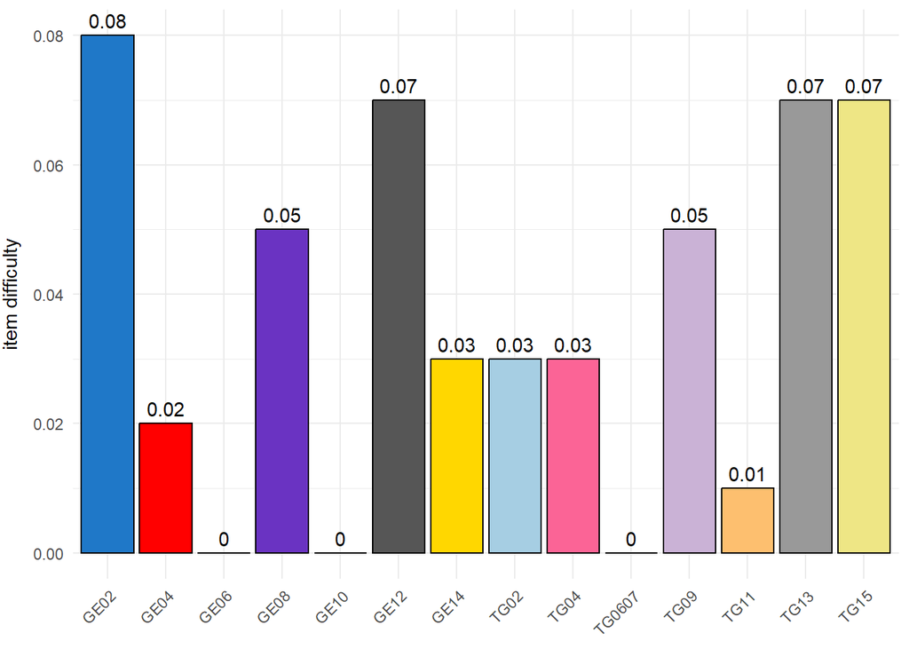

[figure not shown]

```r
item_difficulty <- question_scores %>%
  summarise(across(ends_with("Score_Testlet"),~ mean(.x, na.rm = TRUE))) %>%
  pivot_longer(everything(),names_to = "frage", values_to = "difficulty")

#Zeilen für GE06_Score und GE07_Score zusammenfassen
item_difficulty <- item_difficulty %>%
  mutate(frage=ifelse(frage %in% c("TG06_Score_Testlet", "TG07_Score_Testlet"),"TG0607_Score_Testlet", frage)) %>%
  group_by(frage) %>%
  summarise(difficulty = mean(difficulty,na.rm = T)) %>%
  ungroup()

#Daten cleanen
item_difficulty <- item_difficulty %>%
  mutate(scoring = "Testlet") %>%
  mutate_if(is.numeric, round, digits = 2) %>%
  mutate(frage=str_remove(frage,fixed("_Score_Testlet")))


#mycolors <- colorRampPalette(brewer.pal(8, "Dark2"))(nrow(item_difficulty))
mycolors <- unname(cols25())
ggplot(item_difficulty,aes(x=frage,y=difficulty, fill=frage))+
  geom_bar(color = "black", stat = "identity") +
  #scale_fill_brewer(palette = "PuBu") +
  geom_text(aes(label=difficulty),vjust=-0.5) +
  scale_fill_manual(values=mycolors) +
  theme_minimal()+
  theme(axis.text.x = element_text(angle = 45, hjust = 1),
        axis.title.x = element_blank(),
        axis.title.y = element_text(vjust = 3)) +
  guides(fill="none") +
  labs(y="item difficulty")
```

Aufgrund der Maluspunkte sind die Unterschiede zwischen richtig und falsch beantworteten Fragen deutlich stärker, wodurch sich auch das Mittel über alle Befragten verschiebt.

## Vergleich über alle Score Varianten

Schauen wir uns zuletzt nun die durchschnittlichen Scores über alle drei Score Varianten an.

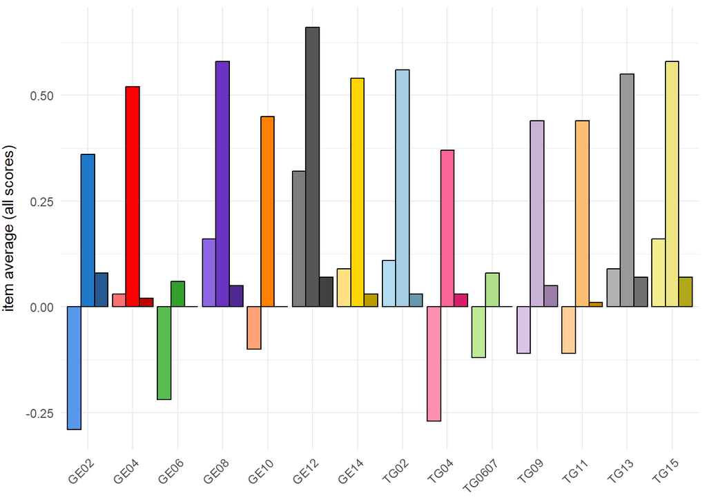

Der linke helle Balken ist das *Formulascoring*, der mittlere Balken das *Standardscoring* und der rechte dunklere Balken die Itemschwierigkeit, also das *Testletscoring*.

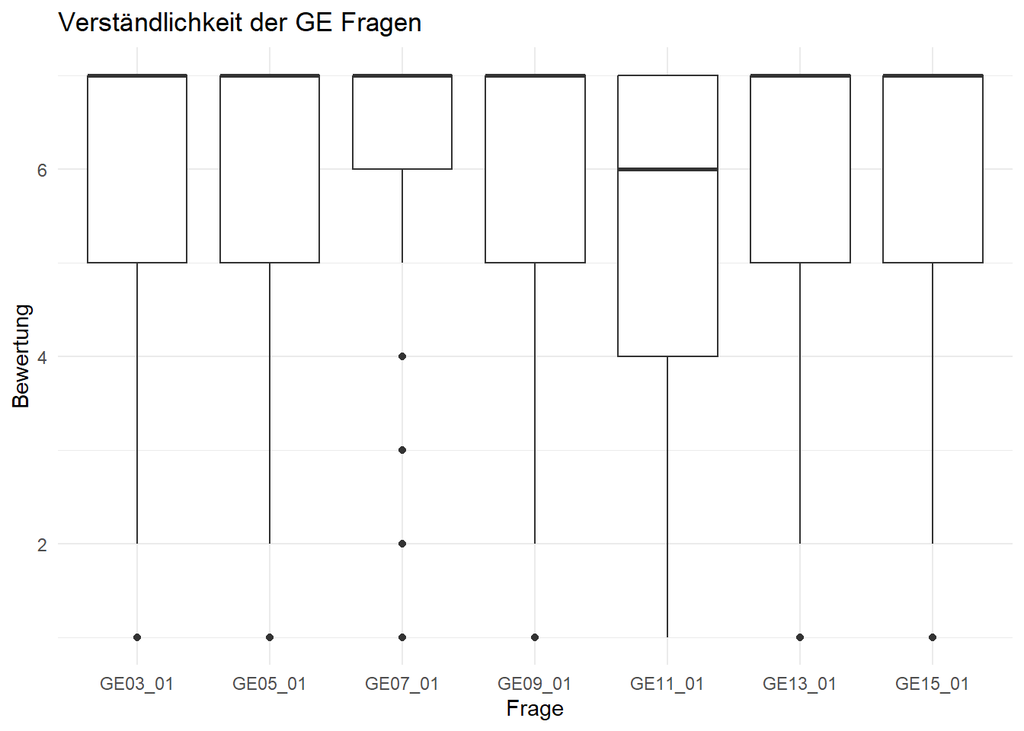

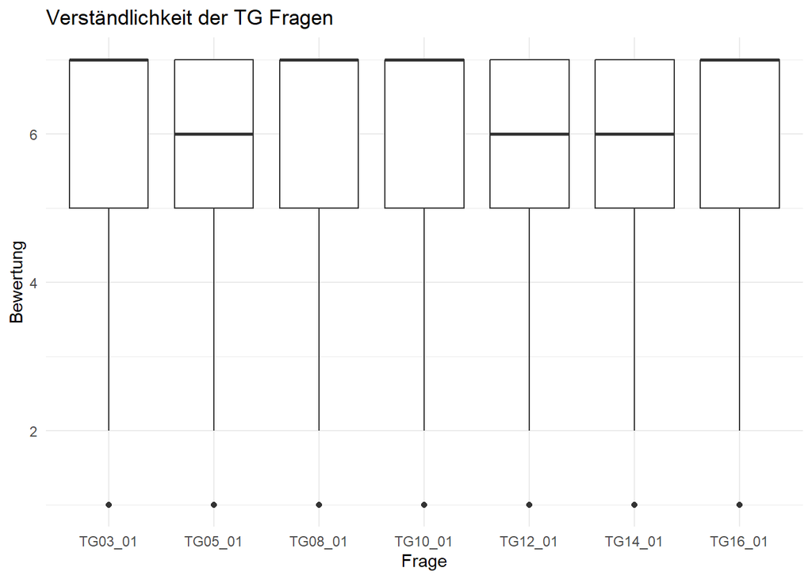

# Vergleich Scoringarten

Wir wollen nun über verschiedene Metriken betrachten, ob sich ein Unterschied in der Art des Scoring zeigt.

## Vorwissen

Als erstes betrachten wir, welches Vorwissen die Befragten haben und wie sich dieses auf den Gesamtscore auswirkt. Wir analysieren erst einmal die Verteilung zu den einzelnen Vorwissensfragen. Da es sich um Expertenbefragungen handelt, sollte ein Großteil der Befragten über viel Vorwissen verfügen.

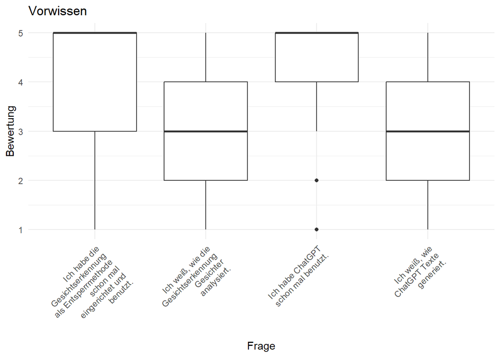

```r
glossar_VK <- c(
  VK01_01 = "Ich habe die Gesichtserkennung als Entsperrmethode schon mal eingerichtet und benutzt.",
  VK01_02 = "Ich weiß, wie die Gesichtserkennung Gesichter analysiert.",
  VK09_01 = "Ich habe ChatGPT schon mal benutzt.",
  VK09_02 = "Ich weiß, wie ChatGPT Texte generiert."
)




#Überführen der Daten in summierte Tabellenform
data_vorwissen_wide <- data.frame(Frage = character(),
                     `1` = integer(),
                     `2` = integer(),
                     `3` = integer(),
                     `4` = integer(),
                     `5` = integer(),
                     stringsAsFactors = FALSE)

for (col in colnames(data_vorwissen)) {
  counts <- table(data_vorwissen[[col]])
  # Fehlende Werte mit 0 auffüllen
  all_counts <- setNames(rep(0, 5), 1:5)
  all_counts[names(counts)] <- counts

  # Zeile zum Resultat-Dataframe hinzufügen
  data_vorwissen_wide <- rbind(data_vorwissen_wide, data.frame(Frage = col,
                                     `1` = all_counts["1"],
                                     `2` = all_counts["2"],
                                     `3` = all_counts["3"],
                                     `4` = all_counts["4"],
                                     `5` = all_counts["5"]))
}

#Umbenennungen zur besseren Lesbarkeit
colnames(data_vorwissen_wide) <- c("Frage", "1", "2", "3", "4", "5")
data_vorwissen_wide$Frage <- glossar_VK[data_vorwissen_wide$Frage]


#Füge Zeilenumbrüche für Diagramm ein
glossar_VK <- data.frame(as.list(glossar_VK)) %>%
  mutate(across(everything(),~ str_wrap(.x,width = 20)))

#Formatiere Daten in Long-Format für Boxplot
data_vorwissen_long <- data %>%
  select(contains('VK')) %>%
  drop_na() %>%
  pivot_longer(cols = everything(), names_to = "VK", values_to = "value")


ggplot(data_vorwissen_long, aes(x = VK, y = value)) +
  geom_boxplot() +
  labs(title = "Vorwissen",
       x = "Frage",
       y = "Bewertung") +
  theme_minimal() +
  scale_x_discrete(labels = glossar_VK) +
  theme(axis.text.x = element_text(angle = 45, hjust = 1))
```

### Korrelation zwischen Vorkenntnissen und Gesamtscore

Als nächsten wollen wir betrachten, inwiefern die selbsteingeschätzen Vorkenntnisse mit dem Gesamtscore korrelieren. Hypothesen:

- Personen, die ihr ML Wissen höher einschätzen, sollten bei einem funktionierenden Test auch eine höhere Gesamtpunktzahl erreichen.
- Personen die mehr Kenntnisse über eine der Technologien haben, sollten bei einem funktionierenden Test auch eine höhere Gesamtpunktzahl erhalten.

```r
kürzel_vk <- str_subset(names(data),"^VK")
kürzel_vk <- c(kürzel_vk,"A012_01", "A013_01", "A015")

cor_knowledge_total <- data.frame(Question = character(),
                      usedScore = character(),
                      Correlation = numeric(),
                      p_value = numeric(),
                      stringsAsFactors = FALSE)


for (vk in kürzel_vk) {
  # Perform the correlation test
  test_result_standard <- cor.test(data[[vk]], question_scores$Score_Standard_Total, method = 'spearman')

  test_result_formula <- cor.test(data[[vk]], question_scores$Score_Formula_Total, method = 'spearman')

  test_result_testlet <- cor.test(data[[vk]], question_scores$Score_Standard_Total, method = 'spearman')

  # Store the results
  cor_knowledge_total <- cor_knowledge_total %>%
    add_row(Question = vk,
            usedScore = "Standard",
            Correlation = test_result_standard$estimate,
            p_value = test_result_standard$p.value) %>%
    add_row(Question = vk,
            usedScore = "Formula",
            Correlation = test_result_formula$estimate,
            p_value = test_result_formula$p.value) %>%
    add_row(Question = vk,
            usedScore = "Testlet",
            Correlation = test_result_testlet$estimate,
            p_value = test_result_testlet$p.value)
}

print(cor_knowledge_total)
```

```
##    Question usedScore Correlation     p_value
## 1   VK01_01  Standard -0.03011676 0.642478411
## 2   VK01_01   Formula -0.02434142 0.707524734
## 3   VK01_01   Testlet -0.03011676 0.642478411
## 4   VK01_02  Standard -0.07925668 0.221195958
## 5   VK01_02   Formula -0.07462721 0.249448270
## 6   VK01_02   Testlet -0.07925668 0.221195958
## 7   VK09_01  Standard  0.17019967 0.008101289
## 8   VK09_01   Formula  0.17441470 0.006639520
## 9   VK09_01   Testlet  0.17019967 0.008101289
## 10  VK09_02  Standard  0.09495962 0.142445675
## 11  VK09_02   Formula  0.10175745 0.115887205
## 12  VK09_02   Testlet  0.09495962 0.142445675
## 13  A012_01  Standard  0.06230156 0.336518725
## 14  A012_01   Formula  0.06391616 0.324121376
## 15  A012_01   Testlet  0.06230156 0.336518725
## 16  A013_01  Standard  0.06149753 0.342803806
## 17  A013_01   Formula  0.05653878 0.383197514
## 18  A013_01   Testlet  0.06149753 0.342803806
## 19     A015  Standard -0.11860690 0.070137983
## 20     A015   Formula -0.11487199 0.079498551
## 21     A015   Testlet -0.11860690 0.070137983
```

```r
#print(filter(cor_knowledge_total,p_value < 0.05))
```

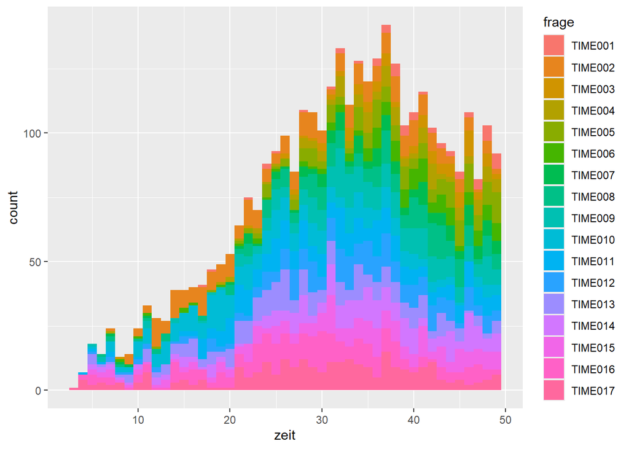

```r
data %>%
  pivot_longer(TIME001:TIME017,
               names_to = "frage",
               values_to = "zeit") %>%
  filter(zeit<50) %>%
  ggplot(aes(x=zeit, fill=frage))+
  geom_histogram(binwidth = 1)
```

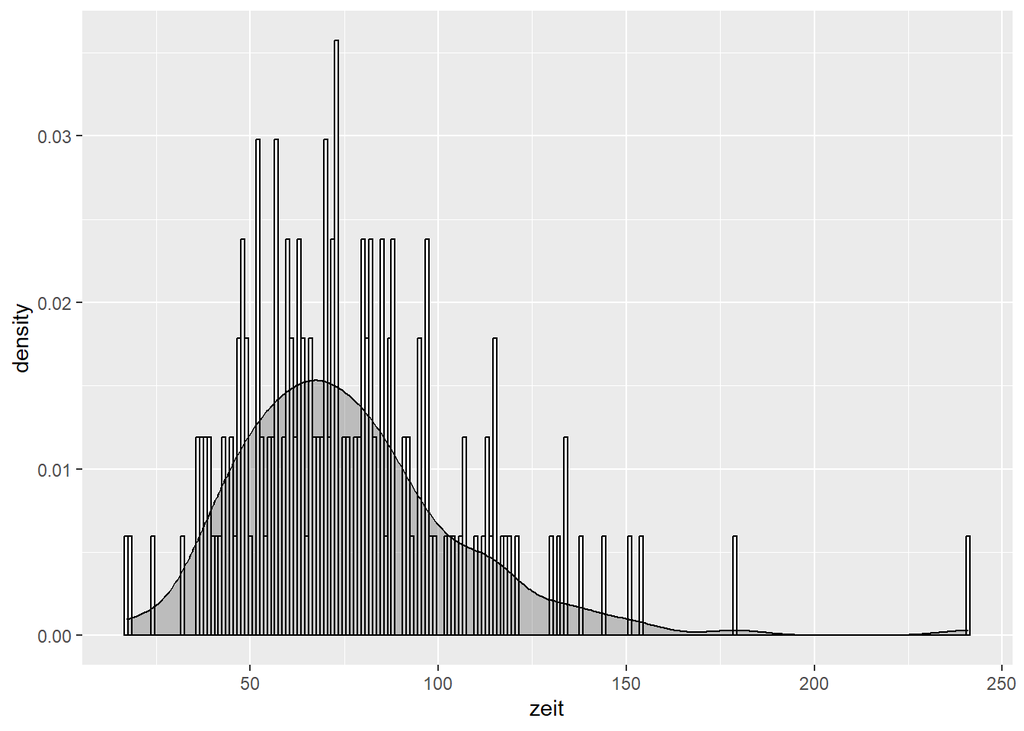

```r
data %>%
  filter(QUESTNNR=="TG2GE_nov") %>%
  pivot_longer(TIME001,
               names_to = "frage",
               values_to = "zeit") %>%
  #filter(zeit<15) %>%
  ggplot(aes(x=zeit))+
  geom_histogram(aes(y=after_stat(density)),colour = "black", fill="white", binwidth = 1) +
  geom_density(alpha=.2, fill="#000000")
```

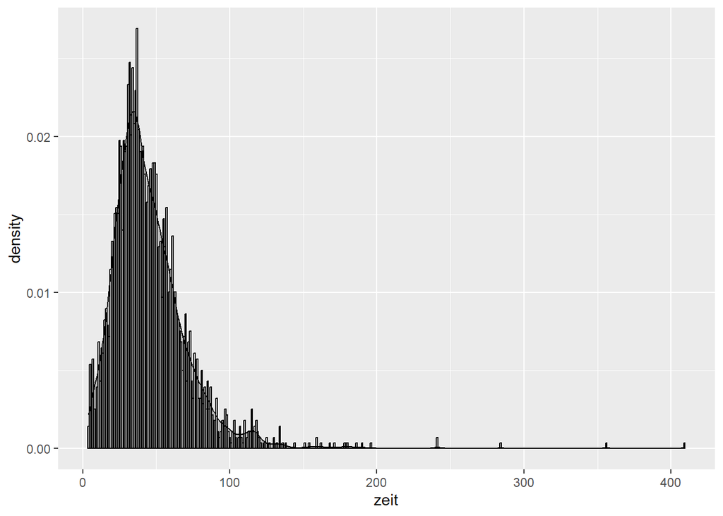

```r
data %>%
  filter(QUESTNNR=="TG2GE_nov") %>%
  pivot_longer(TIME001:TIME017,
               names_to = "frage",
               values_to = "zeit") %>%
  #filter(zeit<15) %>%
  ggplot(aes(x=zeit))+
  geom_histogram(aes(y=after_stat(density)),colour = "black", fill="white", binwidth = 1) +
  geom_density(alpha=.2, fill="#000000")
```